# Data Preparation

Francesca Micocci

6/25/2021

# Import the needed libraries

```r
library(haven)
library(dplyr)
library(data.table)
library(tidyverse)
library(ggplot2)
```

# Data Preparation

Define the working directory and then import the data.

```r
data <- haven::read_stata('Data_panel_TFP.dta')
```

Compute the Spillovers. Remove obs with no Nuts. Transform the data in data.table format. Generate the following columns:

1. *count nuts*, which counts the number of exporters and non-exporters by Nuts2
2. *count nace*, which counts the number of exporters and non-exporters by nace
3. *count nuts nace*, which counts the number of exporters and non-exporters by nace and nuts
4. *spillover_nace*, which counts the share of of exporters and non-exporters by nace
5. *spillover_nuts*, which counts the share of of exporters and non-exporters by nuts
6. *ext_ec_scale*, which counts the share of of exporters and non-exporters by nuts and nace

Then generate a table called **spillover** where you aggregate the columns by mean. As obs within the same unit of interest contain the same value, this trick provides with the aggregates. Select the aggregates for the **exporters** and merge the obtained aggregates with the original dataset. Finally clean the environment of the useless stuff.

```r
dt <- data.table::data.table(data)
dt[, countnace:=.N, by=list(export,nace_2d)]
dt[, countnuts:=.N, by=list(export,nuts2)]
dt[, countnutsnace:=.N, by=list(export,nuts2,nace_2d)]
dt[, spillover_nace:=countnace/.N, by=nace_2d]
dt[, spillover_nuts:=countnuts/.N, by=nuts2]
dt[, ext_ec_scale:=countnutsnace/.N, by=list(nuts2,nace_2d)]

spillover<-stats::aggregate(dt[, c("spillover_nace","spillover_nuts","ext_ec_scale")], list(dt$nace_2d,dt$nuts2,dt$export), mean)
spillover=spillover[spillover$Group.3==1,]
spillover=subset(spillover,select=-c(Group.3))
names(spillover)<-c("nace_2d","nuts2","spillover_nace","spillover_nuts","ext_ec_scale")


data<-merge(data,spillover,by=c("nace_2d","nuts2"),all=TRUE)
data$spillover_nace[is.na(data$spillover_nace)]<- 0

rm(dt,spillover)
```

Fix some missing nuts2, using nuts3

```r
data$nuts2<-ifelse(data$nuts2==""&data$nuts3!="",substr(data$nuts3,1,4),data$nuts2)
```

## Fix some variable formats

Transform to factor some of the variables of interest.

```r
data$nuts2<-as.factor(data$nuts2)
data$nace_2d<-as.factor(data$nace_2d)
```

# Negative Exports

Note there are some negative export. Let’s have a look at the yearly distribution of export class between positive, negative, 0.

Generate a variable called **exportlevel** which takes values:

- *negative* if the export revenues are negative
- *positive* if the export revenues are positive
- *0* otherwise.

Then plot the yearly trend of the number of observations within such three export categories.

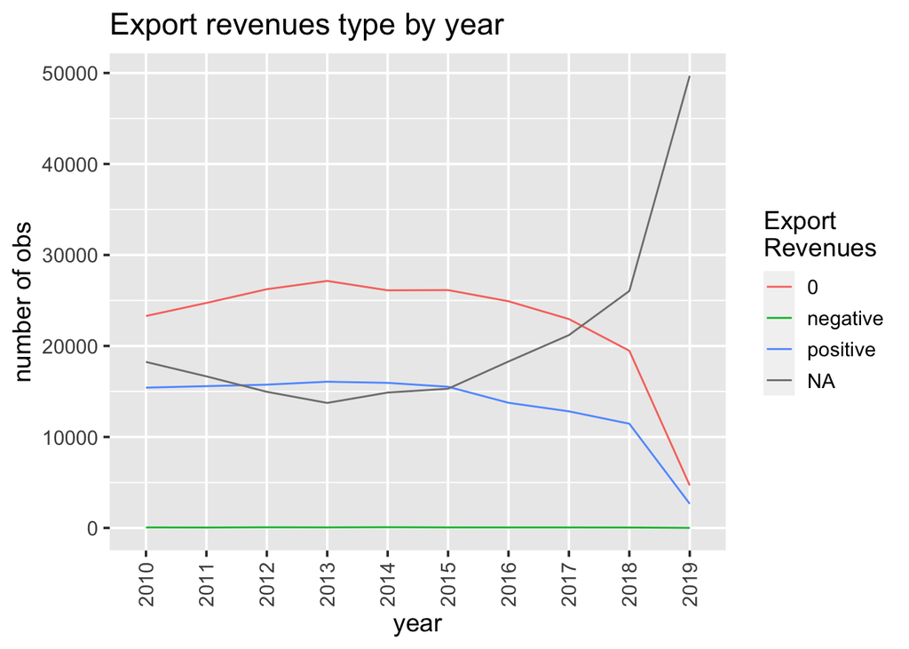

```r
data$exportlevel<-ifelse(data$exportrevenueeur<0,"negative",ifelse(data$exportrevenueeur
                          ==0,"0","positive"))
yearly_counts <- data[which(!is.na(data$export)),] %>%
  count(year, exportlevel)

ggplot(data = yearly_counts, aes(x = as.factor(year), y = n, group = exportlevel,
      color=as.factor(exportlevel))) +geom_line()+labs(title = "Export revenues type by year", x = "year", y = "number of obs", color = "Export\nRevenues") +theme_grey(base_size = 14)+theme(axis.text.x = element_text(angle = 90, vjust = 0.5, hjust=1))
```

The number of negative cases are very limited and we are only interested in positive export quantities so we can classify negative export revenues as zeros

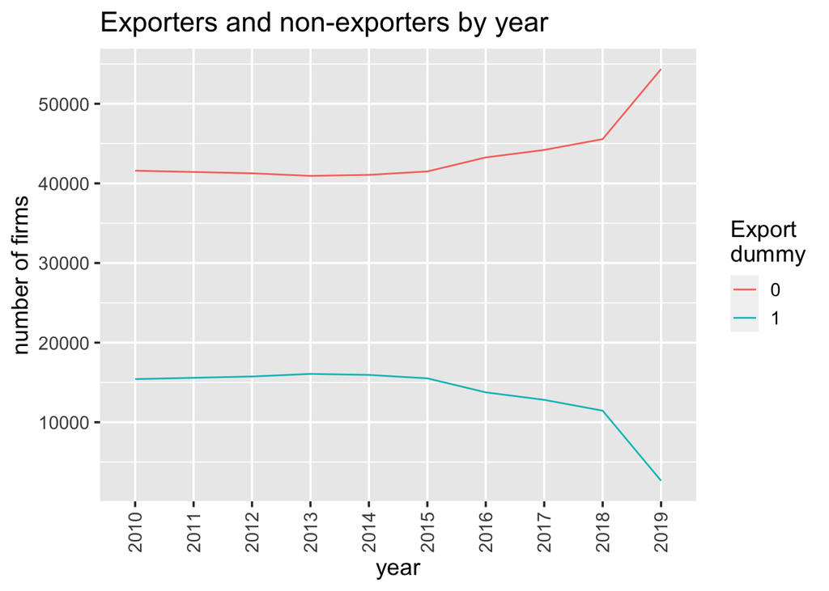

```r
yearly_counts2 <- data[which(!is.na(data$export)),] %>%
  count(year, export)
ggplot(data = yearly_counts2, aes(x = as.factor(year), y = n, group = export,
      color=as.factor(export))) +geom_line()+labs(title = "Exporters and non-exporters by year", x = "year",y = "number of firms", color = "Export\ndummy") +
      theme_grey(base_size = 14)+theme(axis.text.x = element_text(angle = 90, vjust = 0.5, hjust=1))
```

# Remove 2019

Due to the high number of missing in 2019, let us remove such year of data.

```r
data<-subset(data,data$year!="2019")
```

Clear the environment

```r
rm(yearly_counts,yearly_counts2)
```

# Generate variables on exporting history

1. Generate lagged values of exporting activity

```r
data<-data[order(data$bvdidnumber,data$year),]

data[["export_1"]]<-c(NA,data[["export"]][-nrow(data)])
data[["export_1"]][which(!duplicated(data$bvdidnumber))]<-NA

data[["export_2"]]<-c(NA,data[["export_1"]][-nrow(data)])
data[["export_2"]][which(!duplicated(data$bvdidnumber))]<-NA

data[["export_3"]]<-c(NA,data[["export_2"]][-nrow(data)])
data[["export_3"]][which(!duplicated(data$bvdidnumber))]<-NA

data[["export_4"]]<-c(NA,data[["export_3"]][-nrow(data)])
data[["export_4"]][which(!duplicated(data$bvdidnumber))]<-NA

data[["export_5"]]<-c(NA,data[["export_4"]][-nrow(data)])
data[["export_5"]][which(!duplicated(data$bvdidnumber))]<-NA

data[["export_6"]]<-c(NA,data[["export_5"]][-nrow(data)])
data[["export_6"]][which(!duplicated(data$bvdidnumber))]<-NA

data[["export_7"]]<-c(NA,data[["export_6"]][-nrow(data)])
data[["export_7"]][which(!duplicated(data$bvdidnumber))]<-NA

data[["export_8"]]<-c(NA,data[["export_7"]][-nrow(data)])
data[["export_8"]][which(!duplicated(data$bvdidnumber))]<-NA
```

2. Create the table **exporting_history**, whose rows are the firms and the columns are yearly dummies, taking value 1 if firm i is exporting in year t, 0 otherwise.
3. Generate the variable **export_shape**, which is a string composed by a combination of of the yearly dummies.
4. Define the variable **export_type**, based on the export shape.
   - *continuous exporters*: firms exporting all years, whose export shape is “111111111”
   - *switching exporters*: firms which are never exporting from 2011 to t, and always export from t to 2018 (export shapes: “000000001”,“000000011”,“000000111”,“000001111”,“000011111”,“00011111”,“001111111”,“011111111”)
   - *switching non-exporters*: firms which are always exporting from 2011 to t, and never export from t to 2018 (export shapes: “111111110”,“111111100”,“111111000”,“111110000”,“111100000”,“111000000”,“110000000”,“100000000”)
   - *non-exporters*: firms never exporting, whose export shape is “000000000”
   - *discontinuous exporters*: firms exporting with irregualar patterns

```r
exporting_history<-reshape(data[,c("bvdidnumber","year","export")], idvar = "bvdidnumber", timevar = "year", direction = "wide")

exporting_history$export_shape<-paste(exporting_history$export.2010, exporting_history$export.2011,exporting_history$export.2012,exporting_history$export.2013,exporting_history$export.2014,exporting_history$export.2015,exporting_history$export.2016,exporting_history$export.2017,exporting_history$export.2018, sep="")

stopped<-c("111111110","111111100","111111000","111110000","111100000","111000000","110000000","100000000")
started<-c("000000001","000000011","000000111","000001111","000011111","000111111","001111111","011111111")

exporting_history$export_type<-ifelse(exporting_history$export_shape=="111111111","Constant",
                               ifelse(exporting_history$export_shape=="000000000","Non-exporter",
                               ifelse(exporting_history$export_shape %in% stopped,"Switching non-exporters",
                               ifelse(exporting_history$export_shape %in% started,"Switching exporters","Discontinuous"))))

rm(stopped,started)
```

5. Generate the variable **past exporting activity** which, at each year $t$ and firm $i$, contains the number of years such firm $i$ exported in the interval $t=2010$ to $t-1$

```r
index<-grep("export_",colnames(data))
data$past_exp_intensity<-apply(data[index], 1, sum,na.rm=TRUE)
data$past_exp_intensity<-data$past_exp_intensity+data$export
```

Remove the lagged export variables

```r
data<-data[-c(index)]
```

Clear the environment of useless stuff

```r
rm(index)
```

# Export the RData

```r
save.image(file = '/Users/francescamicocci/Documents/Export_project/Data/data_R.RData')
```